# lab3_whitney_willoz

Whitney Willoz

9/27/2021

## Lab 3

```r
dat1 <- readxl::read_xls('GSS.xls')
library(ggplot2)
library(dplyr)
dat <- dat1 %>%
  rename(Year = `Gss year for this respondent`, Happy = `General happiness`,
         relig = `Rs religious preference`, party = `Political party affiliation`,
         gender = `Respondents sex`, edu = `Highest year of school completed`,
         marStatus = `Marital status`, hoursWrk = `Number of hours usually work a week`, id = `Respondent id number`, Ballot = `Ballot used for interview`)
```

1. Find the average years of education for the respondents with each marital status. Arrange your output in a meaningful order and print. Describe any patterns you find.

Answer:The highest average for years of education comes from Never married at 13.4 and lowest average is widowed at 11.2 years.

```r
MarriageAvgEdu <- dat %>%
  filter(nchar(edu) < 3) %>%
  na.omit(edu, marStatus) %>%
  group_by(marStatus)%>%
  summarize(edu_mean = mean(as.numeric(edu), na.rm=TRUE))
MarriageAvgEdu
```

```
## # A tibble: 6 x 2
##   marStatus     edu_mean
##   <chr>            <dbl>
## 1 Divorced          13.1
## 2 Married           13.0
## 3 Never married     13.4
## 4 No answer         15.5
## 5 Separated         11.9
## 6 Widowed           11.2
```

2)Create a single data frame containing records for the better educated respondents with each marital status. A “better educated” respondent is someone who has strictly more years of education than the average among those with the same marital status. Print the structure of the data frame.

```r
btrEdu <- dat %>%
  filter((marStatus == "Never married" & edu > 13.4)|
        (marStatus == "Married" & edu > 13)|
        (marStatus == "Divorced" & edu > 13.1)|
        (marStatus == "Widowed" & edu > 11.2)|
        (marStatus== "Separated" & edu > 11.9))
str(btrEdu)
```

```
## tibble [35,948 x 10] (S3: tbl_df/tbl/data.frame)
##  $ Year     : num [1:35948] 1972 1972 1972 1972 1972 ...
##  $ Happy    : chr [1:35948] "Not too happy" "Not too happy" "Pretty happy" "Not too happy" ...
##  $ relig    : chr [1:35948] "Jewish" "Other" "Protestant" "Jewish" ...
##  $ party    : chr [1:35948] "Ind,near dem" "Not str democrat" "Ind,near dem" "Ind,near dem" ...
##  $ gender   : chr [1:35948] "Female" "Female" "Male" "Male" ...
##  $ edu      : chr [1:35948] "16" "17" "14" "16" ...
##  $ marStatus: chr [1:35948] "Never married" "Married" "Never married" "Never married" ...
##  $ hoursWrk : chr [1:35948] "Not applicable" "Not applicable" "Not applicable" "Not applicable" ...
##  $ id       : num [1:35948] 1 4 6 8 12 13 14 15 16 17 ...
##  $ Ballot   : chr [1:35948] "Not applicable" "Not applicable" "Not applicable" "Not applicable" ...
```

For each of the investigation below, create at least one numerical summary and one appropriate visualization. Write a paragraph to describe your findings and the variables you used.

3)How is the happiness of a respondent related to his/her marriage status? Define that a person is happy if the response to question is “Very happy” or “Pretty happy”.

```r
dat$happy1 <-
  case_when(
    dat$Happy %in% c('Pretty happy', 'Very happy') ~ 'Happy',
    dat$Happy == 'Not too happy' ~ 'Sad',
    TRUE ~ 'Unknown'
  )
table(dat$happy1)
```

```
##
##   Happy     Sad Unknown
##   52386    7668    4760
```

```r
dat$happy2 <-
  case_when(
    dat$Happy %in% c('Pretty happy', 'Very happy') ~ 1,
    dat$Happy == 'Not too happy' ~ -1,
    TRUE ~ 0
  )
meanHappytoMar <- dat %>%
  group_by(marStatus)%>%
  summarize(happy_avg = mean(happy2))
meanHappytoMar
```

```
## # A tibble: 6 x 2
##   marStatus     happy_avg
##   <chr>             <dbl>
## 1 Divorced          0.565
## 2 Married           0.789
## 3 Never married     0.624
## 4 No answer         0.444
## 5 Separated         0.401
## 6 Widowed           0.570
```

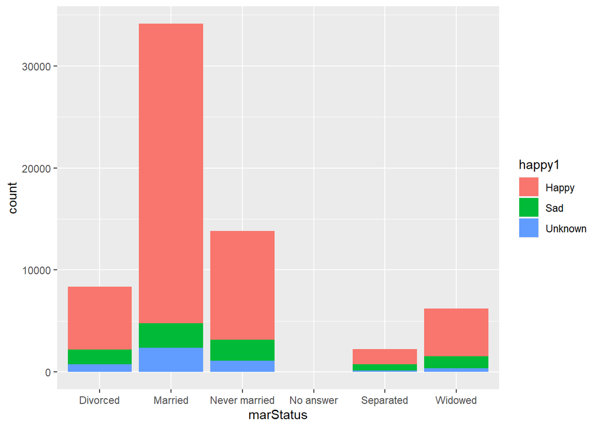

```r
ggplot(dat, aes(marStatus, fill = happy1)) + geom_bar()
```

4)Does party affiliation affect the relationship you found in the last question?

Answer:Overall, married not strong democrats and republicans are overall the happiest or the highest in volume.Next would be married Strong democrats or independents.

```r
meanHappywParty <- dat %>%
  group_by(marStatus, party)%>%
  summarize(happy_avg = mean(happy2))
meanHappywParty
```

```
## # A tibble: 58 x 3
## # Groups:   marStatus [6]
##    marStatus party              happy_avg
##    <chr>     <chr>                  <dbl>
##  1 Divorced  Ind,near dem           0.558
##  2 Divorced  Ind,near rep           0.639
##  3 Divorced  Independent            0.515
##  4 Divorced  No answer              0.525
##  5 Divorced  Not str democrat       0.551
##  6 Divorced  Not str republican     0.636
##  7 Divorced  Other party            0.482
##  8 Divorced  Strong democrat        0.526
##  9 Divorced  Strong republican      0.615
## 10 Married   Don't know             1
## # ... with 48 more rows
```

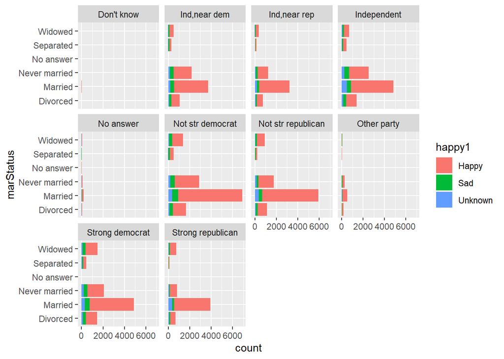

```r
ggplot(dat, aes(marStatus, fill=happy1)) + geom_bar() + coord_flip() + facet_wrap(~party)
```

5)How is religion related to education?

Answer: People who practice hinduism have the highest average of years of education followed by jewish.

```r
avgEduByRelig <- dat %>%
  group_by(relig) %>%
  filter(nchar(edu) < 3)%>%
  summarize(edu_mean = mean(as.numeric(edu), na.rm = TRUE))
avgEduByRelig
```

```
## # A tibble: 15 x 2
##    relig                   edu_mean
##    <chr>                      <dbl>
##  1 Buddhism                    14.9
##  2 Catholic                    12.8
##  3 Christian                   13.3
##  4 Don't know                  12.5
##  5 Hinduism                    16.5
##  6 Inter-nondenominational     13.7
##  7 Jewish                      15.0
##  8 Moslem/islam                14.0
##  9 Native american             13.0
## 10 No answer                   13.8
## 11 None                        13.6
## 12 Orthodox-christian          14.7
## 13 Other                       13.8
## 14 Other eastern               14.6
## 15 Protestant                  12.6
```

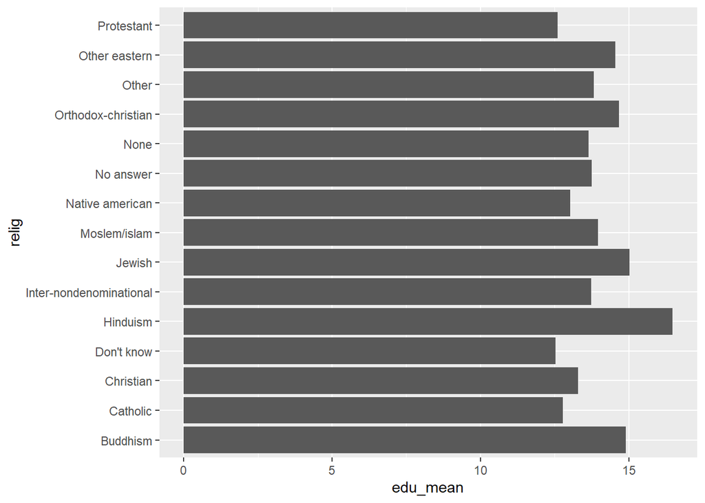

```r
 dat %>%
  group_by(relig) %>%
  filter(nchar(edu) < 3)%>%
  summarize(edu_mean = mean(as.numeric(edu), na.rm = TRUE)) %>%
  ggplot(aes(relig,edu_mean)) + geom_bar(stat = 'identity') + coord_flip()
```